# **Week-7 Python Programming**

## **Testing, Dequeuing, and More**

### *Author: Ujjwal Karki*

## Introduction

It is the basic algorithms and structures and application of different data structures in this language which has been discussed in this file regarding the meaning of Python programming language. The first, of course, is the Fibonacci sequence for which I have implemented this first a recursive form of the solution and then an optimised version using memoization. The optimized method reduces on computation that is not productive, and hence has a higher performance particularly when the input value is large. I also attempted at some point to pull some minor numbers out of the list using set checking which is far superior to plain looping. They demonstrated why and how independent decisions about suitable data structures and strategies can help to achieve the optimal outcomes.

Besides, in the file, I also provide the elaborated information about various forms of queue implementations. I contrasted the standard list-based implementation of the queue where elements must shift positions for dequeuing with the optimized deque structure from the collections module. The deque strategy will show that the decision about which tools to use can influence the rate, which is why it gives O(1) for enqueued and dequed operations. In general, this file helps learners to learn about Python programming language with a focus on making it fast and for solving practical problems.

### Types of testing:

- Unit testing
- Integration testing
- Functional testing
- End-to-End testing (E2E)
- Regression testing

### Memooization/dynamic programming example

```python
def fib_series(n): # time complexity (O(2^n))
    if n <=1:
        return n

    return fib_series(n-1) + fib_series(n-2)

print(fib_series(4))

# Optimizing the above code

memo = {0:1,1:1}

def opz_fib_series(n):

    if n in memo:
        return memo[n]

    fib_num = opz_fib_series(n-1) + opz_fib_series(n-2)

    # Store the result in the memmo dictionary to avoid redundant calculation.
    memo[n] = fib_num
    return fib_num

opz_fib_series(100)
```

```
3
```

```
573147844013817084101
```

### Use Dict/Set (Hashmaps) to optimize the search

```python
numbers = [1,1,2,2,4,10,10]
unq_numbers = []
for i in numbers:
    if not i in unq_numbers:
        unq_numbers.append(i)

print(unq_numbers)

def num_in_list(numbers,num):
    set_num = set(numbers)
    if num in set_num:
        return True
    return False

num_in_list(numbers,6)
```

```
[1, 2, 4, 10]
```

```
False
```

### Data Structure Selection

```python
from collections import deque

#### Queue implementation

# Without optimization: Using list (O(n) for dequeuing)
queue = [1,2,3]
queue.append(4) # Enqueue (O(1))
queue.pop(0) # Dequeue (O(n))

# OPtimized: Using deque (O(1))
queue_deque = deque([1,2,3])
queue_deque.append(4) # Enqueue (O(1))
queue_deque.popleft() # Dequeue (O(1))
```

```
1
```

### Home Work

- Searching for elements in a collection (Use Dict)
  - Write a function so that from a given list of length n, if n element exists on the list return True, else False
- Queue-based problems
  - FIFO and LIFO (use `deque` from `collection`)
    - Task: Simulate FIFO and LIFO queue with list and with deuq and profile

```python
def element_exists(lst, n):

    element_dict = {element: True for element in lst}
    return element_dict.get(n, False)

my_list = [1, 2, 3, 4, 5]
print(element_exists(my_list, 3))
print(element_exists(my_list, 6))

from collections import deque

def fifo_lifo_simulation():
    operations = 5
    data = list(range(operations))

    # FIFO Simulation with list

    fifo_list = []
    for item in data:
        fifo_list.append(item)
        print(fifo_list)
    while fifo_list:
        fifo_list.pop(0)
        print(fifo_list)


    # FIFO Simulation with deque

    fifo_deque = deque()
    for item in data:
        fifo_deque.append(item)  # Enqueue
        print(fifo_deque)
    while fifo_deque:
        fifo_deque.popleft()  # Dequeue
        print(fifo_deque)


    # LIFO Simulation with list

    lifo_list = []
    for item in data:
        lifo_list.append(item)  # Push
        print(lifo_list)
    while lifo_list:
        lifo_list.pop()  # Pop
        print(lifo_list)


    # LIFO Simulation with deque

    lifo_deque = deque()
    for item in data:
        lifo_deque.append(item)  # Push
        print(lifo_deque)
    while lifo_deque:
        lifo_deque.pop()  # Pop
        print(lifo_deque)

# Running the simulation
fifo_lifo_simulation()

# To use the profiling we can simply save this code in .py file and in the terminal run: !python3 -m cProfile file_name.py
```

```
True
False
[0]
[0, 1]
[0, 1, 2]
[0, 1, 2, 3]
[0, 1, 2, 3, 4]
[1, 2, 3, 4]
[2, 3, 4]
[3, 4]
[4]
[]
deque([0])
deque([0, 1])
deque([0, 1, 2])
deque([0, 1, 2, 3])
deque([0, 1, 2, 3, 4])
deque([1, 2, 3, 4])
deque([2, 3, 4])
deque([3, 4])
deque([4])
deque([])
[0]
[0, 1]
[0, 1, 2]
[0, 1, 2, 3]
[0, 1, 2, 3, 4]
[0, 1, 2, 3]
[0, 1, 2]
[0, 1]
[0]
[]
deque([0])
deque([0, 1])
deque([0, 1, 2])
deque([0, 1, 2, 3])
deque([0, 1, 2, 3, 4])
deque([0, 1, 2, 3])
deque([0, 1, 2])
deque([0, 1])
deque([0])
deque([])
```

## Code profiling and analysis

Command line profiling:

```python
!python3 -m cProfile main.py
```

[output not shown]

[output cut: 336 more lines]

## Using python's built-in libraries

```python
import math
from collections import deque, Counter

# Custom
def custom_sqrt(x):
    return x ** 0.5

# Optimized using math.sqrt()
def optimized_sqrt(x):
    return math.sqrt(x)

# Custom factorial
def custom_factorial(n):
    result = 1
    for i in range(1, n + 1):
        result *= i
    return result

# Optimized using math factorial
print(math.factorial(10))
```

```
3628800
```

LRU (Least recently used)

```python
from functools import lru_cache

@lru_cache(maxsize=None) # Cache all results

def fibonacci(n):
    if n<2:
        return n
    return fibonacci(n-1) + fibonacci(n-2)

print(fibonacci(50))
```

```
12586269025
```

### Homework

- Explore `itertools` for memory efficient iteration tasks

### Reference counting

```python
import sys

def reference_count_example():
    a = []
    print(f"Reference count for 'a':{sys.getrefcount(a)}")

    b = a
    print(f"Reference count for 'a' after assigning b = a:{sys.getrefcount(a)}")
    print(f"Reference count for 'b':{sys.getrefcount(b)}")

    c = b
    print(f"Reference count for 'a' after assigning c = b:{sys.getrefcount(a)}")
    print(f"Reference count for 'b' after assigning c = b:{sys.getrefcount(b)}")
    print(f"Reference count for 'c':{sys.getrefcount(c)}")

    # Now, deleting the references

    del b
    print(f"Reference count for 'a' after deleting 'b':{sys.getrefcount(a)}")

    del c
    print(f"Reference count for 'a' after deleting 'c':{sys.getrefcount(a)}")

reference_count_example()
```

```
Reference count for 'a':2
Reference count for 'a' after assigning b = a:3
Reference count for 'b':3
Reference count for 'a' after assigning c = b:4
Reference count for 'b' after assigning c = b:4
Reference count for 'c':4
Reference count for 'a' after deleting 'b':3
Reference count for 'a' after deleting 'c':2
```

### Global Interpreter Lock (GIL)

GIL limits multi-threaded preformance in CPU-bound tasks

```python
import threading
import time

def sum_of_squares(n):
    total = sum(i * i for i in range(n))
    print(f"Sum of squares up to {n}: {total}")

# Measure time for multi-threaded execution
def threaded_execution():
    threads = []
    start_time = time.time()
    # Create threads
    for _ in range(2):
        t = threading.Thread(target=sum_of_squares, args=(10_000_000,))
        threads.append(t)
        t.start()

    # Wait for all threads to complete
    for t in threads:
        t.join()

    print(f"Time taken (threads): {time.time() - start_time:.2f} seconds")

# Measure time for single-threaded execution
def single_threaded_execution():
    start_time = time.time()
    sum_of_squares(10_000_000)
    sum_of_squares(10_000_000)
    print(f"Time taken (single thread): {time.time() - start_time:.2f} seconds")

print("Running with Multi-Threads:")
threaded_execution()
print("\nRunning Single-Threaded:")
single_threaded_execution()
```

```
Running with Multi-Threads:
Sum of squares up to 10000000: 333333283333335000000
Sum of squares up to 10000000: 333333283333335000000
Time taken (threads): 3.56 seconds

Running Single-Threaded:
Sum of squares up to 10000000: 333333283333335000000
Sum of squares up to 10000000: 333333283333335000000
Time taken (single thread): 3.57 seconds
```

## Creating a virtual env in python

=====================================================  
Linux commands:

- python3 -m venv "DataScience"
- source DataScience/bin/activate
- Exporting or say freezing the versions of packages: pip freeze > requirements.txt

## **HomeWork**

`Task 1:`From the Top 120 best-selling mobile datasets data perform following tasks:

- Download the top 120 best-selling mobile phones.csv CSV file
- Perform Data Cleaning
- Perform Data Visualization
  - Create a histogram of the Units Sold (million) column to visualize the distribution of units sold across all mobile models
  - Top Manufacturers:
    - Create a bar chart showing the top 10 manufacturers by total units sold
  - Yearly Trends in Units Sold
    - Create a line plot showing the total units sold per year to visualize any trends over time
- Data Analysis
  - Find and display the top 10 mobile models with the highest units sold
  - Identify High-Selling Years for Each Manufacturer
- Clustering Mobile Models by Sales Performance

```python
import pandas as pd

df = pd.read_csv('Data/top 120 best-selling mobile phones.csv')
df.head()
```

|  | Rank | Manufacturer | Model | Form Factor | Smartphone? | Year | Units Sold (million ) |
| --- | --- | --- | --- | --- | --- | --- | --- |
| 0 | 1 | Nokia | 1100 | Bar | False | 2003 | 250.0 |
| 1 | 2 | Nokia | 1110 | Bar | False | 2005 | 247.5 |
| 2 | 3 | Apple | iPhone 6 & 6 Plus | Touchscreen | True | 2014 | 222.4 |
| 3 | 4 | Nokia | 105 Series | Bar | False | 2013 | 200.0 |
| 4 | 5 | Apple | iPhone 6S & 6S Plus | Touchscreen | True | 2015 | 174.1 |

```python
# Data cleaning
print(df.isnull().sum())
print(df.duplicated().sum())

print(df.dtypes)
```

```
Rank                     0
Manufacturer             0
Model                    0
Form Factor              0
Smartphone?              0
Year                     0
Units Sold (million )    0
dtype: int64
0
Rank                       int64
Manufacturer              object
Model                     object
Form Factor               object
Smartphone?                 bool
Year                       int64
Units Sold (million )    float64
dtype: object
```

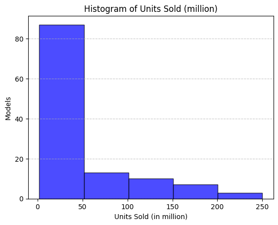

[figure not shown]

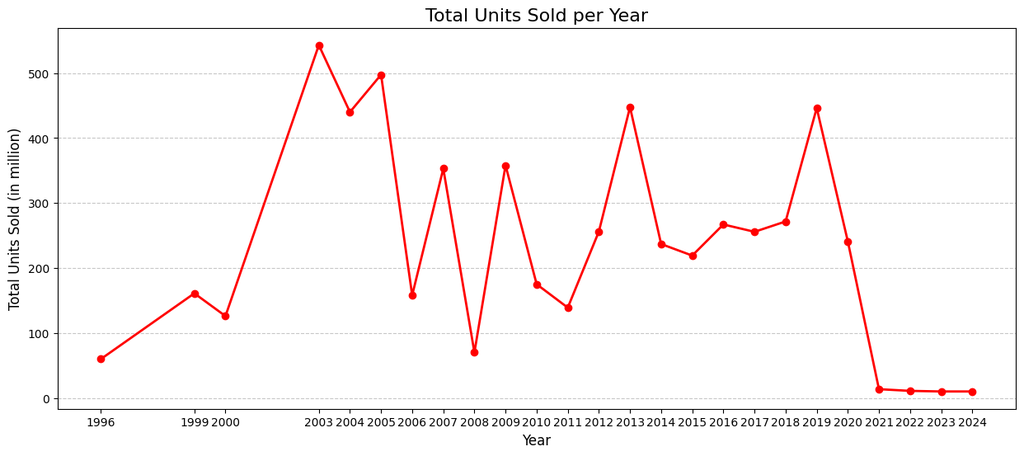

```python
# Data Visualization

'''
Creating a histogram of the Units Sold (million) to visualize the distribution of units sold across all mobile models
'''
import matplotlib.pyplot as plt

plt.hist(df['Units Sold (million )'], bins = 5, color='blue',edgecolor='black', alpha=0.7)
plt.title('Histogram of Units Sold (million)')
plt.xlabel('Units Sold (in million)')
plt.ylabel('Models')
plt.grid(axis='y', linestyle='--', alpha=0.7)
plt.show()

'''
Creating a bar chart to show the top 10 manufacturers by total units sold
'''

plt.figure(figsize=(10,6))
plt.bar(df['Model'].head(10),df['Units Sold (million )'].head(10), color='yellow', edgecolor='black', alpha=0.7)
plt.title('Top 10 Manufacturers as per units sold')
plt.xlabel('Models', fontsize=12)
plt.ylabel('Units Sold (in million)', fontsize=12)
plt.xticks(rotation=90)
plt.grid(axis='y', linestyle='--', alpha=0.7)
plt.show()

'''
Creating a line plot to show the units sold per year to visualize trends over time
'''
# Aggregate units sold by year
total_units_per_year = df.groupby('Year')['Units Sold (million )'].sum().reset_index()

plt.figure(figsize=(15,6))
plt.plot(total_units_per_year['Year'],total_units_per_year['Units Sold (million )'], marker='o', color='red', linestyle='-', linewidth=2)
plt.title('Total Units Sold per Year', fontsize=16)
plt.xlabel('Year', fontsize=12)
plt.ylabel('Total Units Sold (in million)', fontsize=12)
plt.grid(axis='y', linestyle='--', alpha=0.7)
plt.xticks(total_units_per_year['Year'], fontsize=10)
plt.show()
```

```python
'''
DATA ANALYSIS
'''

# Since the data is alrady in descending order as per the units sold
# Displaying the top 10 mobile models with the highest units sold
print(df['Model'].head(10))

# Identifying the high-selling years for each manufacturer

units_per_manufacturer_per_year = df.groupby(['Manufacturer','Year'])['Units Sold (million )'].sum().reset_index()

print(units_per_manufacturer_per_year)

high_selling_year_per_manufacturer = units_per_manufacturer_per_year.loc[
        units_per_manufacturer_per_year.groupby('Manufacturer')['Units Sold (million )'].idxmax()
    ]

print(high_selling_year_per_manufacturer)
```

```
0                                    1100
1                                    1110
2                       iPhone 6 & 6 Plus
3                              105 Series
4                     iPhone 6S & 6S Plus
5                               iPhone 5S
6                                    3210
7                       iPhone 7 & 7 Plus
8             iPhone11, 11Pro & 11Pro Max
9    iPhone XR, iPhone XS & iPhone XS Max
Name: Model, dtype: object
     Manufacturer  Year  Units Sold (million )
0           Apple  2007                    6.0
1           Apple  2009                   35.0
2           Apple  2010                   50.0
```

[output cut: 25 more lines]

## **Clustering Mobile Models by Sales Performance**

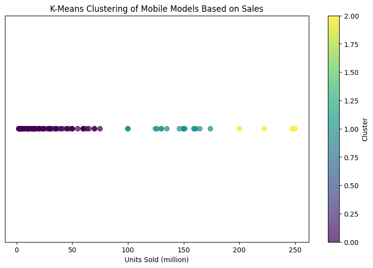

```
Cluster Centers (mean sales per cluster):
[[ 22.51958763]
 [140.08947368]
 [229.975     ]]
```

```python
from sklearn.cluster import KMeans
from sklearn.preprocessing import StandardScaler
import matplotlib.pyplot as plt

# Select relevant features for clustering: 'Units Sold (million)' and 'Manufacturer' (optional)
# For clustering, we can use just the 'Units Sold (million)', but you could use more features if needed
clustering_data = df[['Units Sold (million )']]

# Scale the data (important for K-Means)
scaler = StandardScaler()
scaled_data = scaler.fit_transform(clustering_data)

# Apply K-Means clustering
kmeans = KMeans(n_clusters=3, random_state=42)  # You can change the number of clusters (n_clusters)
df['Cluster'] = kmeans.fit_predict(scaled_data)

# Plotting the clusters
plt.figure(figsize=(10, 6))
plt.scatter(df['Units Sold (million )'], [1]*len(df), c=df['Cluster'], cmap='viridis', s=50, alpha=0.7)
plt.title('K-Means Clustering of Mobile Models Based on Sales')
plt.xlabel('Units Sold (million)')
plt.yticks([])  # Hide y-axis as it's not necessary
plt.colorbar(label='Cluster')
plt.show()

# Optionally, check the cluster centers
print("Cluster Centers (mean sales per cluster):")
print(scaler.inverse_transform(kmeans.cluster_centers_))
```

## **HomeWork**

`Task 2:`From the binance datasets data perform following tasks

- Download the binance-dataset.csv CSV file
- Perform Data Cleaning and Manipulation
  - Handle missing data
  - Convert open_time, close_time, open_time_utc, close_time_utc to datetime format
- Perform Data Visualization
  - Plot a line graph showing the closing price (close) over time
  - Create a line plot showing the total trading volume (volume) over time to visualize market activity and trading volume
- Data Analysis
  - Identify the date and time when the maximum and minimum closing prices occurred
  - Calculate the average volume traded by the day of the week and create a bar plot
- Build Linear Regression to Predict Closing Price using open, high,low and volume

```python
# Loading the dataset

data = pd.read_csv('Data/binance-dataset.csv')
data.head()
```

|  | open_time | open | high | low | close | volume | close_time | quote_asset_volume | number_of_trades | taker_buy_base_asset_volume | taker_buy_quote_asset_volume | ignore | open_time_utc | close_time_utc | open_time_min | close_time_min |
| --- | --- | --- | --- | --- | --- | --- | --- | --- | --- | --- | --- | --- | --- | --- | --- | --- |
| 0 | 1652400000000 | 0.00032 | 0.00049 | 0.00031 | 0.00047 | 4.032332e+08 | 1652400059999 | 163509.572433 | 1276 | 2.233801e+08 | 89172.973422 | 0 | 2022-05-13 00:00:00 | 2022-05-13 00:00:59 | 0 | 1 |
| 1 | 1652400060000 | 0.00047 | 0.00055 | 0.00042 | 0.00049 | 3.467135e+08 | 1652400119999 | 171487.017111 | 1691 | 1.722357e+08 | 85252.153831 | 0 | 2022-05-13 00:01:00 | 2022-05-13 00:01:59 | 1 | 2 |
| 2 | 1652400120000 | 0.00049 | 0.00052 | 0.00048 | 0.00051 | 2.064851e+08 | 1652400179999 | 103019.589015 | 976 | 1.127482e+08 | 56587.930244 | 0 | 2022-05-13 00:02:00 | 2022-05-13 00:02:59 | 2 | 3 |
| 3 | 1652400180000 | 0.00052 | 0.00059 | 0.00051 | 0.00058 | 2.723594e+08 | 1652400239999 | 152790.423528 | 1163 | 1.495032e+08 | 83916.042608 | 0 | 2022-05-13 00:03:00 | 2022-05-13 00:03:59 | 3 | 4 |
| 4 | 1652400240000 | 0.00057 | 0.00060 | 0.00032 | 0.00035 | 5.888936e+08 | 1652400299999 | 258685.424191 | 2566 | 2.240415e+08 | 100513.534527 | 0 | 2022-05-13 00:04:00 | 2022-05-13 00:04:59 | 4 | 5 |

```python
'''
DATA CLEANING AND MANIPULATION
'''

# Converting timestamps to datetime format
data['open_time'] = pd.to_datetime(data['open_time'], unit='ms')
data['close_time'] = pd.to_datetime(data['close_time'], unit='ms')
data['open_time_utc'] = pd.to_datetime(data['open_time_utc'])
data['close_time_utc'] = pd.to_datetime(data['close_time_utc'])

# Handle Missing data
data = data.dropna()

# Displaying updated data info
data.info()
```

```
<class 'pandas.core.frame.DataFrame'>
RangeIndex: 5400 entries, 0 to 5399
Data columns (total 16 columns):
 #   Column                        Non-Null Count  Dtype
---  ------                        --------------  -----
 0   open_time                     5400 non-null   datetime64[ns]
 1   open                          5400 non-null   float64
 2   high                          5400 non-null   float64
 3   low                           5400 non-null   float64
 4   close                         5400 non-null   float64
 5   volume                        5400 non-null   float64
 6   close_time                    5400 non-null   datetime64[ns]
 7   quote_asset_volume            5400 non-null   float64
 8   number_of_trades              5400 non-null   int64
 9   taker_buy_base_asset_volume   5400 non-null   float64
 10  taker_buy_quote_asset_volume  5400 non-null   float64
 11  ignore                        5400 non-null   int64
 12  open_time_utc                 5400 non-null   datetime64[ns]
 13  close_time_utc                5400 non-null   datetime64[ns]
 14  open_time_min                 5400 non-null   int64
 15  close_time_min                5400 non-null   int64
dtypes: datetime64[ns](4), float64(8), int64(4)
memory usage: 675.1 KB
```

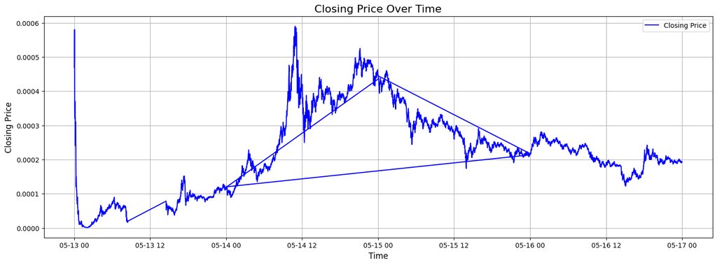

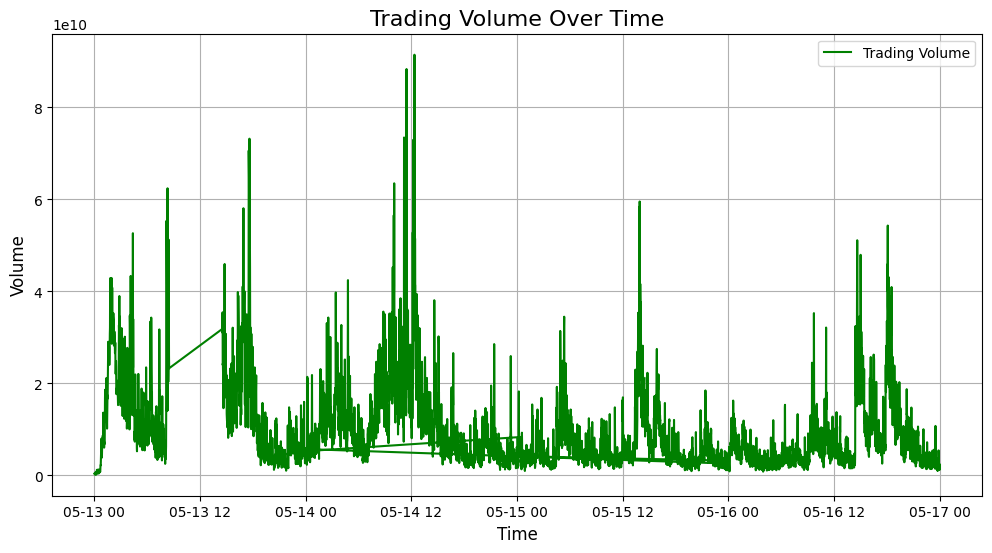

```python
'''
PERFORMING DATA VISUALIZATION
'''

# Plot closing price over time
plt.figure(figsize=(18, 6))
plt.plot(data['close_time'], data['close'], label='Closing Price',color='blue')
plt.title('Closing Price Over Time', fontsize=16)
plt.xlabel('Time', fontsize=12)
plt.ylabel('Closing Price', fontsize=12)
plt.legend()
plt.grid()
plt.show()

# Plot trading volume over time
plt.figure(figsize=(12, 6))
plt.plot(data['close_time'], data['volume'], label='Trading Volume', color='green')
plt.title('Trading Volume Over Time', fontsize=16)
plt.xlabel('Time', fontsize=12)
plt.ylabel('Volume', fontsize=12)
plt.legend()
plt.grid()
plt.show()
```

```
Maximum Closing Price:
close                            0.00059
close_time    2022-05-14 10:53:59.999000
Name: 3173, dtype: object

Minimum Closing Price:
close                           0.000001
close_time    2022-05-13 02:00:59.999000
Name: 120, dtype: object
```

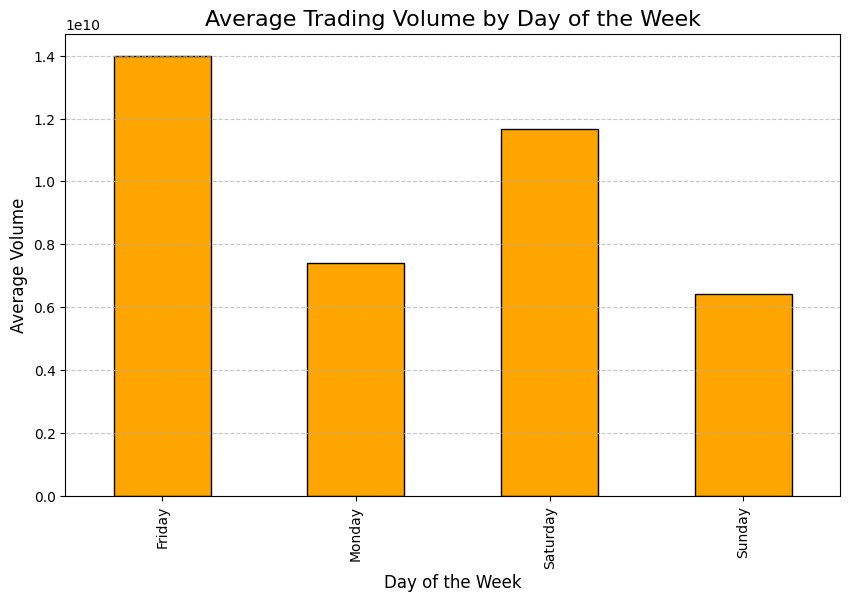

```python
'''
PERFORMING DATA ANALYSIS
'''

# Find the maximum and minimum closing prices
max_close = data.loc[data['close'].idxmax()]
min_close = data.loc[data['close'].idxmin()]

print("Maximum Closing Price:")
print(max_close[['close', 'close_time']])

print("\nMinimum Closing Price:")
print(min_close[['close', 'close_time']])

# Add a column for the day of the week
data['day_of_week'] = data['close_time'].dt.day_name()

# Calculate average volume by day of the week
avg_volume_by_day = data.groupby('day_of_week')['volume'].mean().sort_index()

# Bar plot for average volume by day of the week
plt.figure(figsize=(10, 6))
avg_volume_by_day.plot(kind='bar', color='orange', edgecolor='black')
plt.title('Average Trading Volume by Day of the Week', fontsize=16)
plt.xlabel('Day of the Week', fontsize=12)
plt.ylabel('Average Volume', fontsize=12)
plt.grid(axis='y', linestyle='--', alpha=0.7)
plt.show()
```

```python
'''
BUILDING LINEAR REGRESSION TO PREDICT CLOSING PRICE USING OPEN,
HIGH, LOW, AND VOLUME
'''

from sklearn.model_selection import train_test_split
from sklearn.linear_model import LinearRegression
from sklearn.metrics import root_mean_squared_error, r2_score, mean_squared_error

# Features and target
X = data[['open', 'high', 'low', 'volume']]
y = data['close']

# Train-test split
X_train, X_test, y_train, y_test = train_test_split(X, y, test_size=0.3, random_state=42)

# Train linear regression model
model = LinearRegression()
model.fit(X_train, y_train)

# Predictions
y_pred = model.predict(X_test)

# Model evaluation
mse = mean_squared_error(y_test, y_pred)
print(f"Mean Squared Error: {mse}")
rmse = root_mean_squared_error(y_test, y_pred)
r2 = r2_score(y_test, y_pred)

print(f"RMSE: {rmse}")
print(f"R²: {r2}")
```

```
Mean Squared Error: 1.0789634802479656e-11
RMSE: 3.284757951886205e-06
R²: 0.999278643647225
```